# Predicting Quality of Exercise Using Data From Wearable Tech

Sarah Agatoni

### Summary

Using devices such as Jawbone Up, Nike FuelBand, and Fitbit it is now possible to collect a large amount of data about personal activity relatively inexpensively. One thing that people regularly do is quantify how much of a particular activity they do, but they rarely quantify how well they do it.

In this project, I use [data](http://web.archive.org/web/20161224072740/http:/groupware.les.inf.puc-rio.br/har) from accelerometers on the belt, forearm, arm, and dumbell of 6 participants to predict the manner in which they did the exercises. I begin by handling missing values and selecting features. I then split the train data into training and validation sets, from which I build and test a decision tree and random forest model. I finish by applying the most accurate model to the test data.

**Environment**

```r
if (!require("pacman")) install.packages("pacman"); library(pacman)
pacman::p_load(caret, ggplot2, randomForest, naniar, rpart)
```

### Data

*read in training data*

```r
data <- read.csv("proj_train.csv", na.strings = c("NA", "#DIV/0!", ""))
dim(data)
```

```
## [1] 19622   160
```

*note that some features have many missing values*

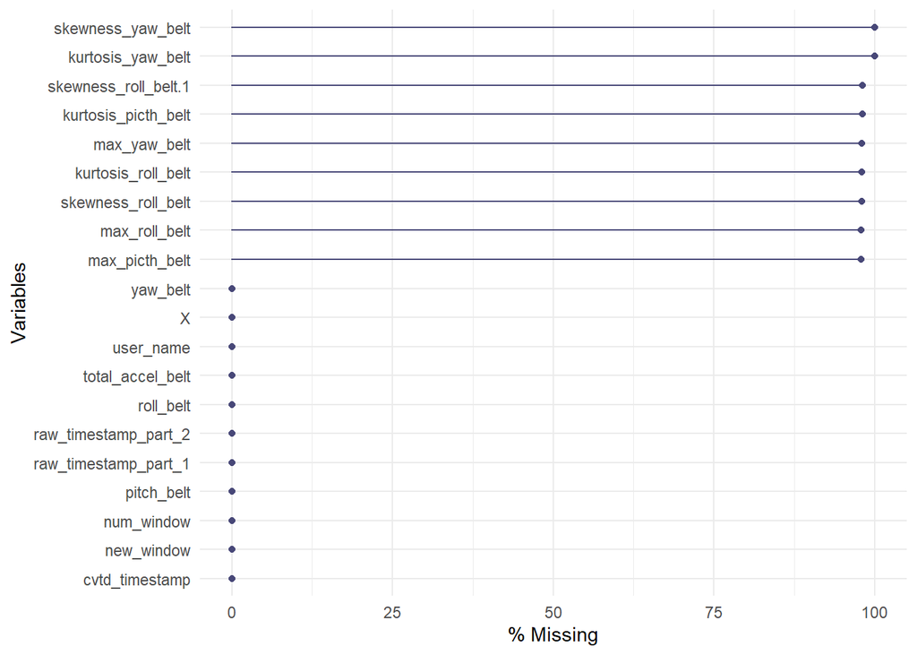

```r
gg_miss_var(data[, 1:20], show_pct = TRUE)
```

```r
newdata <- data[sapply(data, naniar::prop_miss) < 0.8]
dim(newdata)
```

```
## [1] 19622    60
```

*eliminate identifiers and timestamps such as `user_name` `cvtd_timestamp`, all contained in columns 1 through 5*

```r
newdata <- newdata[, -(1:5)]
dim(newdata)
```

```
## [1] 19622    55
```

*split data into training and validation sets*

```r
set.seed(100)
inTrain <- caret::createDataPartition(newdata$classe, p = 0.75, list = FALSE)
training <- newdata[inTrain, ]
validation <- newdata[-inTrain, ]
```

### Decision Tree Model

*fit a decision tree model with `classe` as the dependent variable:*

```r
set.seed(101)
decFit <- rpart(classe ~ ., data = training, method = "class")
```

*predict `classe` in validation set*

```r
decPred <- predict(decFit, validation[, -55], type="class")
```

*confusion matrix*

```r
confusionMatrix(decPred, validation$classe)
```

```
## Confusion Matrix and Statistics
##
##           Reference
## Prediction    A    B    C    D    E
##          A 1247  209   36   68   23
##          B   29  530   57   30   34
##          C   17   65  678  112   73
##          D   77  117   62  514  118
##          E   25   28   22   80  653
##
## Overall Statistics
##
##                Accuracy : 0.7386
##                  95% CI : (0.726, 0.7508)
##     No Information Rate : 0.2845
##     P-Value [Acc > NIR] : < 2.2e-16
##
##                   Kappa : 0.6682
##
##  Mcnemar's Test P-Value : < 2.2e-16
##
## Statistics by Class:
##
##                      Class: A Class: B Class: C Class: D Class: E
## Sensitivity            0.8939   0.5585   0.7930   0.6393   0.7248
## Specificity            0.9042   0.9621   0.9341   0.9088   0.9613
## Pos Pred Value         0.7877   0.7794   0.7175   0.5788   0.8082
## Neg Pred Value         0.9554   0.9008   0.9553   0.9278   0.9395
## Prevalence             0.2845   0.1935   0.1743   0.1639   0.1837
## Detection Rate         0.2543   0.1081   0.1383   0.1048   0.1332
## Detection Prevalence   0.3228   0.1387   0.1927   0.1811   0.1648
## Balanced Accuracy      0.8991   0.7603   0.8635   0.7740   0.8430
```

**The decision tree model has an in-sample error of about 26%.** This is higher than we’d like.

### Random Forest Model

*Next, we try a random forest model:*

```r
rfControl <- trainControl(method = "cv", number = 3, verboseIter = FALSE)
rfFit <- train(classe ~ ., data = training, method = "rf", trControl = rfControl)
```

*apply random forest model to validation set*

```r
rfPred <- predict(rfFit, validation[, -55])
confusionMatrix(rfPred, validation$classe)
```

```
## Confusion Matrix and Statistics
##
##           Reference
## Prediction    A    B    C    D    E
##          A 1395    0    0    0    0
##          B    0  949    2    0    0
##          C    0    0  853    2    0
##          D    0    0    0  802    0
##          E    0    0    0    0  901
##
## Overall Statistics
##
##                Accuracy : 0.9992
##                  95% CI : (0.9979, 0.9998)
##     No Information Rate : 0.2845
##     P-Value [Acc > NIR] : < 2.2e-16
##
##                   Kappa : 0.999
##
##  Mcnemar's Test P-Value : NA
##
## Statistics by Class:
##
##                      Class: A Class: B Class: C Class: D Class: E
## Sensitivity            1.0000   1.0000   0.9977   0.9975   1.0000
## Specificity            1.0000   0.9995   0.9995   1.0000   1.0000
## Pos Pred Value         1.0000   0.9979   0.9977   1.0000   1.0000
## Neg Pred Value         1.0000   1.0000   0.9995   0.9995   1.0000
## Prevalence             0.2845   0.1935   0.1743   0.1639   0.1837
## Detection Rate         0.2845   0.1935   0.1739   0.1635   0.1837
## Detection Prevalence   0.2845   0.1939   0.1743   0.1635   0.1837
## Balanced Accuracy      1.0000   0.9997   0.9986   0.9988   1.0000
```

**The random forest model has an in-sample error of less than 1%.** So we use this model to predict `classe` in the testing data.

### Applying Best Model to Test Set

*read in testing data*

```r
test <- read.csv("proj_test.csv", na.strings = c("NA", "#DIV/0!", ""))
```

*create corresponding names and factor levels in test set*

```r
both <- intersect(names(newdata), names(test))
testdata <- test[both]

for (var in both) {
    if (class(data[[var]]) == "factor") {
        levels(testdata[[var]]) <- levels(data[[var]])
    }
}
```

*predict*

```r
predict(rfFit, newdata = testdata)
```

```
##  [1] B A B A A E D B A A B C B A E E A B B B
## Levels: A B C D E
```

__________________________________________________________END__________________________________________________________